# Sanjuanita_Full_Code_NLP_RAG_Project_Notebook

## Problem Statement

### Business Context

The healthcare industry is rapidly evolving, with professionals facing increasing challenges in managing vast volumes of medical data while delivering accurate and timely diagnoses. The need for quick access to comprehensive, reliable, and up-to-date medical knowledge is critical for improving patient outcomes and ensuring informed decision-making in a fast-paced environment.

Healthcare professionals often encounter information overload, struggling to sift through extensive research and data to create accurate diagnoses and treatment plans. This challenge is amplified by the need for efficiency, particularly in emergencies, where time-sensitive decisions are vital. Furthermore, access to trusted, current medical information from renowned manuals and research papers is essential for maintaining high standards of care.

To address these challenges, healthcare centers can focus on integrating systems that streamline access to medical knowledge, provide tools to support quick decision-making, and enhance efficiency. Leveraging centralized knowledge platforms and ensuring healthcare providers have continuous access to reliable resources can significantly improve patient care and operational effectiveness.

**Common Questions to Answer**

**1. Diagnostic Assistance**: "What are the common symptoms and treatments for pulmonary embolism?"

**2. Drug Information**: "Can you provide the trade names of medications used for treating hypertension?"

**3. Treatment Plans**: "What are the first-line options and alternatives for managing rheumatoid arthritis?"

**4. Specialty Knowledge**: "What are the diagnostic steps for suspected endocrine disorders?"

**5. Critical Care Protocols**: "What is the protocol for managing sepsis in a critical care unit?"

### Objective

As an AI specialist, your task is to develop a RAG-based AI solution using renowned medical manuals to address healthcare challenges. The objective is to **understand** issues like information overload, **apply** AI techniques to streamline decision-making, **analyze** its impact on diagnostics and patient outcomes, **evaluate** its potential to standardize care practices, and **create** a functional prototype demonstrating its feasibility and effectiveness.

### Data Description

The **Merck Manuals** are medical references published by the American pharmaceutical company Merck & Co., that cover a wide range of medical topics, including disorders, tests, diagnoses, and drugs. The manuals have been published since 1899, when Merck & Co. was still a subsidiary of the German company Merck.

The manual is provided as a PDF with over 4,000 pages divided into 23 sections.

## Installing and Importing Necessary Libraries and Dependencies

```python
# Installation for GPU llama-cpp-python
# uncomment and run the following code in case GPU is being used
!CMAKE_ARGS="-DLLAMA_CUBLAS=on" FORCE_CMAKE=1 pip install llama-cpp-python==0.2.28 --force-reinstall --no-cache-dir -q

# Installation for CPU llama-cpp-python
# uncomment and run the following code in case GPU is not being used
# !CMAKE_ARGS="-DLLAMA_CUBLAS=off" FORCE_CMAKE=1 pip install llama-cpp-python==0.2.28 --force-reinstall --no-cache-dir -q
```

[output not shown]

**Note**:

- After running the above cell, kindly restart the runtime (for Google Colab) or notebook kernel (for Jupyter Notebook), and run all cells sequentially from the next cell.
- On executing the above line of code, you might see a warning regarding package dependencies. This error message can be ignored as the above code ensures that all necessary libraries and their dependencies are maintained to successfully execute the code in *this notebook*.

```python
# For installing the libraries & downloading models from HF Hub
!pip install huggingface_hub==0.35.3 pandas==2.2.2 tiktoken==0.12.0 pymupdf==1.26.5 langchain==0.3.27 langchain-community==0.3.31 chromadb==1.1.1 sentence-transformers==5.1.1 numpy==2.3.3 -q
```

[output not shown]

```python
!pip -q install -U \
  langchain langchain-community chromadb huggingface-hub tiktoken pandas \
  llama-cpp-python==0.2.28 \
  sentence-transformers==2.6.1 \
  numpy==1.26.4
```

[output not shown]

**Note**:

- After running the above cell, kindly restart the runtime (for Google Colab) or notebook kernel (for Jupyter Notebook), and run all cells sequentially from the next cell.
- On executing the above line of code, you might see a warning regarding package dependencies. This error message can be ignored as the above code ensures that all necessary libraries and their dependencies are maintained to successfully execute the code in *this notebook*.

```python
!pip -q install -U langchain langchain-community langchain-text-splitters
```

```python
pip install --upgrade langchain langchain-core langchain-community
```

```python
#Libraries for processing dataframes,text
import json,os
import tiktoken
import pandas as pd

#Libraries for Loading Data, Chunking, Embedding, and Vector Databases
from langchain_text_splitters import RecursiveCharacterTextSplitter
from langchain_community.document_loaders import PyMuPDFLoader
from langchain_community.embeddings.sentence_transformer import SentenceTransformerEmbeddings
from langchain_community.vectorstores import Chroma

#Libraries for downloading and loading the llm
from huggingface_hub import hf_hub_download
from llama_cpp import Llama
from langchain_core.retrievers import BaseRetriever
```

## Question Answering using LLM

```python
from google.colab import drive
drive.mount('/content/drive')
```

```python
md_pdf_path = ('/content/drive/MyDrive/Python Course/medical_diagnosis_manual.pdf')
```

#### Response

```python
def response(query,max_tokens=128,temperature=0,top_p=0.95,top_k=50):
    model_output = llm(
      prompt=query,
      max_tokens=max_tokens,
      temperature=temperature,
      top_p=top_p,
      top_k=top_k
    )

    return model_output['choices'][0]['text']
```

### Query 1: What is the protocol for managing sepsis in a critical care unit?

- Give IV fluids to help stabilize the patients condition
- Start antibiotics early and adjust them once test results are available
- Remove or drain the source of infection if needed
- Continuously monitor the patients vital signs and key lab values in the ICU
- Use medications to raise blood pressure if fluids alone are not enough
- Provide oxygen support, including a ventilator if breathing becomes difficult
- Offer general supportive care, such as managing blood sugar and using steroids when required

### Query 2: What are the common symptoms for appendicitis, and can it be cured via medicine? If not, what surgical procedure should be followed to treat it?

- Pain usually starts near the stomach or belly button and later moves to the lower right side
- Common symptoms include nausea, vomiting, loss of appetite, and mild fever
- Pain often gets worse when moving, coughing, or being touched.
- Appendicitis usually cannot be cured with medicine alone
- The standard treatment is surgery to remove the appendix
- Antibiotics are often given before or after surgery to prevent infection

### Query 3: What are the effective treatments or solutions for addressing sudden patchy hair loss, commonly seen as localized bald spots on the scalp, and what could be the possible causes behind it?

- Sudden hair loss in small patches is commonly called alopecia areata
- It may happen due to the bodys immune system attacking hair follicles
- Treatments can include steroid medicines, topical creams or hair-growth products
- In some cases hair may grow back on its own over time
- Stress or genetics may increase the chance of this condition

### Query 4: What treatments are recommended for a person who has sustained a physical injury to brain tissue, resulting in temporary or permanent impairment of brain function?

- The first priority is making sure the person can breathe and has stable blood pressure.
- Oxygen is provided to protect the brain
- Surgery may be needed in serious cases to reduce pressure on the brain.
- Doctors closely monitor the patient to prevent further damage
- Rehabilitation therapy is often required for recovery after the injury

### Query 5: What are the necessary precautions and treatment steps for a person who has fractured their leg during a hiking trip, and what should be considered for their care and recovery?

- Keep the injured leg still using a splint or support
- Apply ice and raise the leg to reduce pain and swelling
- Seek medical care to check how serious the fracture is
- Treatment may involve a cast, splint, or surgery depending on severity
- Follow care instructions during recovery to ensure proper healing
- Avoid keeping the leg immobile for too long to prevent stiffness and weakness

## Question Answering using LLM with Prompt Engineering

### Query 2: What are the common symptoms for appendicitis, and can it be cured via medicine? If not, what surgical procedure should be followed to treat it?

Parameter tuning prevented irrelevant details and kept the response aligned with the question scope.

### Query 3: What are the effective treatments or solutions for addressing sudden patchy hair loss, commonly seen as localized bald spots on the scalp, and what could be the possible causes behind it?

The model remained focused on relevant clinical information without hallucination

### Query 4: What treatments are recommended for a person who has sustained a physical injury to brain tissue, resulting in temporary or permanent impairment of brain function?

The response stayed concise while still covering acute care and rehabilitation phases

### Query 5: What are the necessary precautions and treatment steps for a person who has fractured their leg during a hiking trip, and what should be considered for their care and recovery?

The output remained relevant and avoided unnecessary medical depth

## Data Preparation for RAG

### Loading the Data

```python
pdf_loader = PyMuPDFLoader(md_pdf_path)
```

This method is from Langchain in order to read pdf.

```python
medical_diagnosis = pdf_loader.load()
```

### Data Overview

#### Checking the first 5 pages

```python
for i in range(5):
    print(f"Page Number: {i+1}",end="\n")
    print(medical_diagnosis[i].page_content,end="\n")
```

```
Page Number: 1
saberjtx@gmail.com
8192RNUAW0
meant for personal use by saberjtx@gma
shing the contents in part or full is liable
Page Number: 2
saberjtx@gmail.com
8192RNUAW0
This file is meant for personal use by saberjtx@gmail.com only.
Sharing or publishing the contents in part or full is liable for legal action.
Page Number: 3
Table of Contents
1
Front    ................................................................................................................................................................................................................
1
Cover    .......................................................................................................................................................................................................
2
Front Matter    ...........................................................................................................................................................................................
53
1 - Nutritional Disorders    ...............................................................................................................................................................
53
Chapter 1. Nutrition: General Considerations    .....................................................................................................................
59
Chapter 2. Undernutrition    .............................................................................................................................................................
69
Chapter 3. Nutritional Support    ...................................................................................................................................................
76
Chapter 4. Vitamin Deficiency, Dependency & Toxicity    ..................................................................................................
99
Chapter 5. Mineral Deficiency & Toxicity    ..............................................................................................................................
108
Chapter 6. Obesity & the Metabolic Syndrome    ...............................................................................................................
120
2 - Gastrointestinal Disorders    ..............................................................................................................................................
120
Chapter 7. Approach to the Patient With Upper GI Complaints    ...............................................................................
132
Chapter 8. Approach to the Patient With Lower GI Complaints    ...............................................................................
143
Chapter 9. Diagnostic & Therapeutic GI Procedures    ....................................................................................................
```

[output cut: 287 more lines]

```
Chapter 139. Rickettsiae & Related Organisms    ..........................................................................................................
1431
Chapter 140. Anaerobic Bacteria    ........................................................................................................................................
1450
Chapter 141. Mycobacteria    ...................................................................................................................................................
1470
Chapter 142. Fungi    ...................................................................................................................................................................
1493
Chapter 143. Approach to Parasitic Infections    .............................................................................................................
1496
Chapter 144. Nematodes (Roundworms)    .......................................................................................................................
saberjtx@gmail.com
8192RNUAW0
This file is meant for personal use by saberjtx@gmail.com only.
Sharing or publishing the contents in part or full is liable for legal action.
```

- The first 20 to 40 pages of the pdf are abbreviations and table of contents
- the first 20 to 40 pages also contain editors

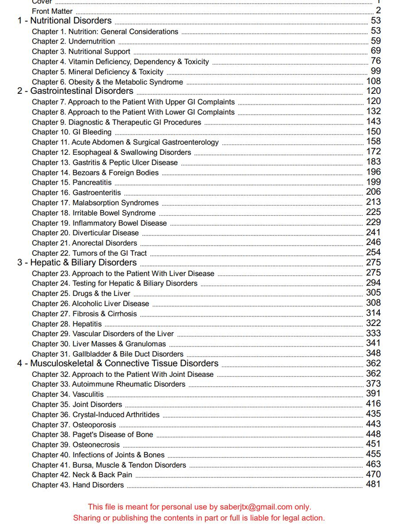

```python
print(medical_diagnosis[2000].page_content[:1000])
```

```
Primary brain lymphomas originate in neural tissue and are usually B-cell tumors. Diagnosis
requires neuroimaging and sometimes CSF analysis (including Epstein-Barr titers) or brain
biopsy. Treatment includes corticosteroids, chemotherapy, and radiation therapy.
Incidence of primary brain lymphomas is increasing, particularly among immunocompromised patients and
the elderly. Lymphomas tend to infiltrate the brain diffusely, often as multicentric masses adjacent to the
ventricles, but may occur as solitary brain masses. Lymphomas may also occur in the meninges, uvea, or
vitreous humor. Most are B-cell tumors, often immunoblastic. The Epstein-Barr virus may contribute to
development of lymphomas in immunocompromised patients. Most patients do not develop subsequent
systemic lymphoma.
Diagnosis
• MRI
• Sometimes CSF analysis or biopsy
MRI can suggest the diagnosis. MRI may be unable to distinguish cerebral toxoplasmosis, which is
common among patients with AIDS, from lymphoma.
If there ar
```

I wanted to check deep into the book if there was any real medical information .

I selected 2,001st page of the pdf , I indexed so its the 2,001 . and it returns the frist 1,000 characters.

#### Checking the number of pages

```python
len(medical_diagnosis)
```

```
4114
```

There are 4,114 pages in the pdf

### Data Chunking

```python
text_splitter = RecursiveCharacterTextSplitter.from_tiktoken_encoder(
    encoding_name='cl100k_base',
    chunk_size=1000,
    chunk_overlap= 150
)
```

In Hugginface : cl100k_base is the name of a specific Byte Pair Encoding BPE tokenizer encoding developed by OpenAI, used primarily with models like GPT-3 5-turbo, GPT-4, and text-embedding-ada-002

```
                     Chunk Size
```

  ```
                  Chunk Overlap
  ```

- I wanted to get a healthy contect overlap.

```python
document_chunks = pdf_loader.load_and_split(text_splitter)
```

This is a variable name that will store the final result: a list of the smaller, processed text segments

```python
len(document_chunks)
```

```
4663
```

4,663 individual text chunks after the splitting process was completed.

we essentially broke down 4,114 pages into 4,663 chunks

```python
document_chunks[54].page_content
```

```
'Clinical Assistant Professor, University of\nBritish Columbia\nHypersensitivity and Inflammatory Disorders;\nNail Disorders\nDOUGLAS J. RHEE, MD\nAssistant Professor, Massachusetts Eye and\nEar Infirmary, Harvard Medical School\nGlaucoma\nMELVIN I. ROAT, MD\nClinical Associate Professor, Wills Eye …
```

```python
i = 54

print("---- Chunk 54 LAST 600 chars ----")
print(document_chunks[i].page_content[-600:])

print("\n---Chunk 55 FIRST 600 chars ----")
print(document_chunks[i+1].page_content[:600])
```

```
---- Chunk 54 LAST 600 chars ----
ncy
Medicine, Penn State Hershey Medical Center;
Adjunct Clinical Professor of Emergency
Medicine, Drexel University College of
Medicine
Approach to the Trauma Patient
ROBERT J. RUBEN, MD
Distinguished University Professor,
Department of Otorhinolaryngology-Head &
Neck Surgery, Albert Einstein College of
Medicine and Montefiore Medical Center
Hearing Loss
The Merck Manual of Diagnosis & Therapy, 19th Edition
Front Matter
43
saberjtx@gmail.com
8192RNUAW0
This file is meant for personal use by saberjtx@gmail.com only.
Sharing or publishing the contents in part or full is liable for legal action.

---Chunk 55 FIRST 600 chars ----
FRED H. RUBIN, MD
Professor of Medicine, University of
Pittsburgh, School of Medicine; Chair,
Department of Medicine, University of
Pittsburgh Medical Center Presbyterian
Shadyside Hospital, Shadyside Campus
Immunization
MICHAEL RUBIN, MD
Professor of Clinical Neurology,
Weill Cornell Medical College; Director,
Neuromuscular Service and EMG Laboratory,
New York Presbyterian Hospital-Cornell
Medical Center
Craniocervical Junction Abnormalities;
Inherited Muscular Disorders; Spinal Cord
Disorders; Peripheral Nervous System and
Motor Unit Disorders
ATENODORO R. RUIZ, Jr., MD
Senior Attending Phys
```

The chunks are sequential with no missing text and no truncation While the semantic overlap between chunks 54 and 55 is minimal due to both chunks belonging to the documents front matter the chunk boundaries are continuous and correctly ordered

### Embedding

```python
embedding_model = SentenceTransformerEmbeddings(model_name='thenlper/gte-large')
```

I am initializing a sentence-transformer embedding model gte-large that converts text chunks into 1024 dimensional semantic vectors for similarity search and retrieval in the RAG system

```python
embedding_1 = embedding_model.embed_query(document_chunks[54].page_content)
embedding_2 = embedding_model.embed_query(document_chunks[55].page_content)
```

to stay consistent I used text content of chunk 54 to convert into a numerical vector and same for 55. This code converts two text chunks into fixed-length semantic vectors so they can be compared and indexed for retrieval in a RAG system

```python
print("Dimension of the embedding vector ",len(embedding_1))
len(embedding_1)==len(embedding_2)
```

```
Dimension of the embedding vector  1024
```

```
True
```

This means that EVERY chunk is converted into a 1024 dimenional numberical vector.

### Vector Database

```python
out_dir = 'medical_db'

if not os.path.exists(out_dir):
  os.makedirs(out_dir)
```

I created a variable that defines the directory where the vector database will be stroed on a disk and check the batabase direcotry exists and creates it if it does not.

```python
vectorstore = Chroma.from_documents(
    document_chunks,
    embedding_model,
    persist_directory=out_dir
)
```

creates the chroma vector database by embedding all my documents chunks and persting the vecotrs to a disk

```python
vectorstore = Chroma(persist_directory=out_dir,embedding_function=embedding_model)
```

I realoaded the previously saved chroma vector database from the disk so it can be queried without re embedding all the time.

```python
vectorstore.embeddings
```

```
HuggingFaceEmbeddings(client=SentenceTransformer(
  (0): Transformer({'max_seq_length': 512, 'do_lower_case': False}) with Transformer model: BertModel
  (1): Pooling({'word_embedding_dimension': 1024, 'pooling_mode_cls_token': False, 'pooling_mode_mean_tokens': True, 'pooling_mode_max_tokens': False, 'pooling_mode_mean_sqrt_len_tokens': False, 'pooling_mode_weightedmean_tokens': False, 'pooling_mode_lasttoken': False, 'include_prompt': True})
  (2): Normalize()
), model_name='thenlper/gte-large', cache_folder=None, model_kwargs={}, encode_kwargs={}, multi_process=False, show_progress=False)
```

This line simply exposes the embedding function attached to the Chroma vector store confirming which embedding model is being used to encode queries and documents

```python
vectorstore.similarity_search("sepsis",k=3)
```

```
[Document(metadata={'keywords': '', 'total_pages': 4114, 'file_path': '/content/drive/MyDrive/Python Course/medical_diagnosis_manual.pdf', 'source': '/content/drive/MyDrive/Python Course/medical_diagnosis_manual.pdf', 'subject': '', 'author': '', 'format': 'PDF 1.7', 'page': 2453, 'moddate': '2025-1…
 Document(metadata={'creationdate': '2012-06-15T05:44:40+00:00', 'moddate': '2025-12-15T00:35:12+00:00', 'title': 'The Merck Manual of Diagnosis & Therapy, 19th Edition', 'modDate': 'D:20251215003512Z', 'creator': 'Atop CHM to PDF Converter', 'author': '', 'subject': '', 'trapped': '', 'creationDate…
 Document(metadata={'producer': 'pdf-lib (https://github.com/Hopding/pdf-lib)', 'format': 'PDF 1.7', 'source': '/content/drive/MyDrive/Python Course/medical_diagnosis_manual.pdf', 'author': '', 'keywords': '', 'creator': 'Atop CHM to PDF Converter', 'subject': '', 'creationdate': '2012-06-15T05:44:4…
```

Here I search within the vector database and return the three most similar document chunks to the word sepsis .

### Retriever

```python
retriever = vectorstore.as_retriever(
    search_type='similarity',
    search_kwargs={'k': 4}
)
```

This retriever is configured to return the top four most semantically similar document chunks for a query, providing sufficient medical context across definitions, symptoms, and management while minimizing irrelevant information

```python
question = "What is the protocol for managing sepsis in a critical care unit?"
rel_docs = retriever.invoke(question)
rel_docs
```

```
[Document(metadata={'total_pages': 4114, 'modDate': 'D:20251215003512Z', 'creator': 'Atop CHM to PDF Converter', 'moddate': '2025-12-15T00:35:12+00:00', 'source': '/content/drive/MyDrive/Python Course/medical_diagnosis_manual.pdf', 'keywords': '', 'trapped': '', 'creationdate': '2012-06-15T05:44:40+…
 Document(metadata={'keywords': '', 'producer': 'pdf-lib (https://github.com/Hopding/pdf-lib)', 'moddate': '2025-12-15T00:35:12+00:00', 'format': 'PDF 1.7', 'modDate': 'D:20251215003512Z', 'creationDate': 'D:20120615054440Z', 'title': 'The Merck Manual of Diagnosis & Therapy, 19th Edition', 'author'…
 Document(metadata={'format': 'PDF 1.7', 'title': 'The Merck Manual of Diagnosis & Therapy, 19th Edition', 'keywords': '', 'subject': '', 'page': 2453, 'modDate': 'D:20251215003512Z', 'moddate': '2025-12-15T00:35:12+00:00', 'creator': 'Atop CHM to PDF Converter', 'file_path': '/content/drive/MyDrive…
 Document(metadata={'producer': 'pdf-lib (https://github.com/Hopding/pdf-lib)', 'creationdate': '2012-06-15T05:44:40+00:00', 'trapped': '', 'creator': 'Atop CHM to PDF Converter', 'subject': '', 'total_pages': 4114, 'title': 'The Merck Manual of Diagnosis & Therapy, 19th Edition', 'author': '', 'sou…
```

Chunk 1: looks like is giving general info on ICU and monitoring care

chunk 2: talks about antibiotics and pharmac managment for sepsis and its shock

chunk 3 : sepsis defenition and diagnostic

chunk 4 : looks like a step by step sepsis treament

The chunks alltogether give us ICU context with sepsis definitionand detailed managment steps . This demontrates that the retriver is assembing evidence for clinical question answering.

```python
model_name_or_path = "TheBloke/Mistral-7B-Instruct-v0.2-GGUF"
model_basename = "mistral-7b-instruct-v0.2.Q6_K.gguf"
```

```python
model_path = hf_hub_download(
    repo_id=model_name_or_path,
    filename=model_basename
)
```

```python
llm = Llama(
    model_path=model_path,
    n_ctx=5000,
    n_gpu_layers=38,
    n_batch=512
)
```

```
AVX = 1 | AVX_VNNI = 0 | AVX2 = 1 | AVX512 = 1 | AVX512_VBMI = 0 | AVX512_VNNI = 0 | FMA = 1 | NEON = 0 | ARM_FMA = 0 | F16C = 1 | FP16_VA = 0 | WASM_SIMD = 0 | BLAS = 1 | SSE3 = 1 | SSSE3 = 1 | VSX = 0 |
```

### System and User Prompt Template

```python
qna_system_message = """
You are a medical assistant supporting medical students and clinical staff.
Your task is to answer medical questions using ONLY the information provided in the context.

The context will begin with the token: ###Context.
The user question will begin with the token: ###Question.

Answer the question accurately, concisely, and in a clinical tone.
Do NOT add information that is not present in the context.
Do NOT mention the context, documents, or sources explicitly in your answer.

If the answer cannot be determined from the context, respond exactly with:
"I don't know."
"""
```

The system prompt defines the assistants medical role and grounding rules. The user prompt injects retrieved clinical context and the question for RAG-based answering

I thought about the audience who would use this pdf that is why the sysemt messege is for medical staff . I used a clinical tone to help the LLM with the response.

```python
qna_user_message_template = """
###Context
Here are excerpts from a medical reference that may be relevant to the question.
{context}

###Question
{question}
"""
```

### Response Function

```python
def generate_rag_response(
    user_input,
    max_tokens=256,
    temperature=0,
    top_p=0.95,
    top_k=50
):
    global qna_system_message, qna_user_message_template

    # new retriver chunks new API
    relevant_document_chunks = retriever.invoke(user_input)

    # Combine document chunks into a single context
    context_for_query = "\n\n".join([d.page_content for d in relevant_document_chunks])

    # Fill the user template
    user_message = qna_user_message_template.format(
        context=context_for_query,
        question=user_input
    )

    # Final prompt
    prompt = qna_system_message + "\n" + user_message

    # Generate response
    try:
        output = llm(
            prompt,
            max_tokens=max_tokens,
            temperature=temperature,
            top_p=top_p,
            top_k=top_k
        )
        return output["choices"][0]["text"].strip()
    except Exception as e:
        return f"Sorry, I encountered the following error:\n{e}"
```

I updated the response function to match the newer retriever API and adjusted the prompt to clearly separate the medical context from the question so the model doesnt hallucinate. I used a low temperature with controlled topp and topk to keep answers consistent and factual. I also used a larger token limit so the model can fully explain medical protocols when needed

## Question Answering using RAG

### Query 1: What is the protocol for managing sepsis in a critical care unit?

```python
user_input = "What is the protocol for managing sepsis in a critical care unit?"
print(generate_rag_response(user_input))
```

```
Llama.generate: prefix-match hit
```

```
Answer: The protocol for managing sepsis in a critical care unit includes aggressive fluid resuscitation, antibiotics, surgical excision of infected or necrotic tissues and drainage of pus, supportive care, normalization of blood glucose, and replacement-dose corticosteroids. Patients should be moni…
```

I noticed that the answer was unorganized and lacks structure

### Query 2: What are the common symptoms for appendicitis, and can it be cured via medicine? If not, what surgical procedure should be followed to treat it?

```python
user_input = " What are the common symptoms for appendicitis, and can it be cured via medicine? If not, what surgical procedure should be followed to treat it?"
print(generate_rag_response(user_input))
```

```
Llama.generate: prefix-match hit
```

```
The common symptoms for appendicitis include epigastric or periumbilical pain followed by brief nausea, vomiting, and anorexia; after a few hours, the pain shifts to the right lower quadrant. Pain increases with cough and motion. Classic signs are right lower quadrant direct and rebound tenderness l…

Appendicitis cannot be cured via medicine alone, and surgery is required for treatment. The surgical procedure for appendicitis is an open or laparoscopic appendectomy. If the
```

This query would benefit with more tokens, not really sure how they determine diagnosis. This answer also lacks structure.

### Query 3: What are the effective treatments or solutions for addressing sudden patchy hair loss, commonly seen as localized bald spots on the scalp, and what could be the possible causes behind it?

```python
user_input = "What are the effective treatments or solutions for addressing sudden patchy hair loss, commonly seen as localized bald spots on the scalp, and what could be the possible causes behind it?"
print(generate_rag_response(user_input))
```

```
Llama.generate: prefix-match hit
```

```
Based on the context, the condition being described is alopecia areata. The effective treatments for this condition include corticosteroids (triamcinolone acetonide suspension or potent topical corticosteroids), minoxidil, anthralin, and immunotherapy using diphencyprone or squaric acid dibutylester…
```

I looks like either there should be more information or its cut off . There is no structure . I am not sure at what point the treatment for alopecia starts. I do see the possible causes.

### Query 4: What treatments are recommended for a person who has sustained a physical injury to brain tissue, resulting in temporary or permanent impairment of brain function?

```python
user_input = "What treatments are recommended for a person who has sustained a physical injury to brain tissue, resulting in temporary or permanent impairment of brain function?"
print(generate_rag_response(user_input))
```

```
Llama.generate: prefix-match hit
```

```
Answer: The initial treatment includes ensuring a reliable airway and maintaining adequate ventilation, oxygenation, and blood pressure. Surgery may be needed for patients with more severe injuries to place monitors to track and treat intracranial pressure, decompress the brain if intracranial press…
```

same problem as above , this one also cuts off . However, there is so much in this answer needs to be a bullet or number structure.

### Query 5: What are the necessary precautions and treatment steps for a person who has fractured their leg during a hiking trip, and what should be considered for their care and recovery?

```python
user_input = "What are the necessary precautions and treatment steps for a person who has fractured their leg during a hiking trip, and what should be considered for their care and recovery?"
print(generate_rag_response(user_input))
```

```
Llama.generate: prefix-match hit
```

```
Based on the context, the necessary precautions for a person who has fractured their leg during a hiking trip include:
1. Seeking medical care at once if an odor emanates from within the cast or if a fever develops.
2. Maintaining good hygiene to prevent infection.
3. Using a splint to immobilize the injury, allowing for application of ice and movement.
4. Avoiding prolonged immobilization (more than 3 to 4 weeks) as it can cause stiffness, contractures, and muscle atrophy.
5. Considering early mobilization for rapidly healing injuries to minimize contractures and muscle atrophy.

The treatment steps for a person with a fractured leg include:
1. Analgesics for pain relief.
2. Immobilization using a cast or splint.
3. Surgery if necessary.
4. Rest, ice, compression, and elevation (RICE) to minimize swelling and pain.
5. Periodic application of warmth after 48 hours to relieve pain and speed healing.
6. Regular inspections of the cast's edges and skin around it for
```

In bullet point 6 I noticed there is a cut off . I dont really know what happens after you follow the treatment.

### Fine-tuning

```
                            Sepsis protocol
```

```python
user_input_1 = (
    "Using only the provided context, outline the ICU protocol for managing sepsis/septic shock. "
    "Answer in bullet points under these headings: "
    "1) Immediate actions, 2) Monitoring, 3) Fluids, "
    "4) Antibiotics, 5) Supportive care. "
    "Keep each bullet to 1–2 lines."
)
generate_rag_response(user_input_1, temperature=0.1, max_tokens=350)
```

```
Llama.generate: prefix-match hit
```

```
'###Answer\n1. Immediate actions:\n   - Suspect sepsis based on symptoms (fever, hypotension, oliguria, confusion).\n   - Begin prompt empiric antibiotic therapy after taking specimens for culture and sensitivity.\n   - Initiate fluid resuscitation to maintain adequate tissue perfusion.\n2. Monitori…
```

I structured this question with clear headings and bullet points to organize a complex ICU protocol into immediate actions monitoring, and treatment steps, making the response easier to read and somewhat relevant to medicine

```
                                  Appendicitis
```

```python
user_input_2 = (
    "Using only the provided context, answer these questions about appendicitis: "
    "A) List the common symptoms and signs in bullet points. "
    "B) Can appendicitis be cured with medicine alone? Answer Yes/No and give one sentence why. "
    "C) If surgery is needed, name the procedure(s) mentioned. "
    "Keep each bullet to 1–2 lines."
)
generate_rag_response(user_input_2, temperature=0.1, max_tokens=350)
```

```
Llama.generate: prefix-match hit
```

```
"A) Common symptoms and signs of appendicitis:\n- Epigastric or periumbilical pain followed by brief nausea, vomiting, and anorexia\n- Pain shifts to right lower quadrant after a few hours\n- Pain increases with cough and motion\n- Direct and rebound tenderness located at McBurney's point\n- Additio…
```

after reading the first input I did noticed that it was all unstructured and there was so much information that needed to be in bullet points

This question was broken into symptoms, medical management, and surgical treatment to ensure the model clearly distinguishes between diagnosis and definitive treatment while avoiding incomplete or ambiguous answers

```
                            Patchy hair loss and alopecia areata
```

```python
user_input_3 = (
    "Using only the provided context, for sudden patchy hair loss (localized bald spots): "
    "1) Name the most likely condition, "
    "2) List possible causes/risk factors mentioned, "
    "3) List treatments mentioned. "
    "Format as bullet points and keep each bullet under 2 lines."
)
generate_rag_response(user_input_3, temperature=0.1, max_tokens=350)
```

```
Llama.generate: prefix-match hit
```

```
'- Alopecia areata\n- Sudden patchy hair loss\n- Most likely condition\n- Autoimmune disorder affecting genetically susceptible people\n- Exposure to unclear environmental triggers\n- Discrete circular patches of hair loss\n- Short broken hairs at the margins\n- Nails may be pitted or display trachy…
```

I separated the question into diagnosis, causes and treatments to help the model clearly identify the patients condition first and then explain why it occurs and how it is managed

```
                                Traumatic brain injury
```

```python
user_input_4 = (
    "Using only the provided context, describe recommended treatments and key precautions for traumatic brain injury "
    "(injury to brain tissue causing temporary or permanent impairment). "
    "Answer in bullet points under: 1) Immediate stabilization, 2) Monitoring/tests, 3) Treatments, 4) Complications to watch for. "
    "If the context does not include treatment details, respond exactly: I don't know."
)
generate_rag_response(user_input_4, temperature=0.1, max_tokens=350)
```

```
Llama.generate: prefix-match hit
```

```
'- 1) Immediate stabilization:\n  - Ensure reliable airway and maintain adequate ventilation, oxygenation, and blood pressure.\n  - Surgery may be needed for patients with more severe injury to place monitors to track and treat intracranial pressure, decompress the brain if intracranial pressure is …
```

this prompt was designed to guide the model through stabilization, monitoring, and treatment steps while also allowing it to correctly respond **I dont know** if the retrieved context lacks sufficient information

```
                              Leg fracture during hiking
```

```python
user_input_5 = (
    "Using only the provided context, give first aid and follow-up care for a leg fracture during a hiking trip. "
    "Answer in numbered steps and include: "
    "1) Immediate precautions (immobilization, when to seek urgent care), "
    "2) Pain/swelling control, "
    "3) Immobilization/cast care warnings, "
    "4) Recovery considerations (mobilization, preventing stiffness/atrophy). "
    "Keep each step to 1–2 lines."
)
generate_rag_response(user_input_5, temperature=0.1, max_tokens=350)
```

```
Llama.generate: prefix-match hit
```

```
"1. Immediate precautions: Seek medical care if there's an odor from the cast or fever. Immobilize the leg in a functional position just below heart level. Avoid exertion and keep warm during transport to a medical facility.\n2. Pain/swelling control: Use analgesics as needed for pain relief. Apply …
```

I structured this question in a step by step format to reflect a real world first aid and treatment and recovery considerations.

I wanted to ensure the response follows progression

## Output Evaluation

Let us now use the LLM-as-a-judge method to check the quality of the RAG system on two parameters - retrieval and generation. We illustrate this evaluation based on the answeres generated to the question from the previous section.

- We are using the same Mistral model for evaluation, so basically here the llm is rating itself on how well he has performed in the task.

```python
groundedness_rater_system_message = """
You are tasked with rating AI-generated answers to user questions.

In the input:
- The question begins with ###Question
- The context begins with ###Context
- The AI-generated answer begins with ###Answer

Evaluation criteria:
Rate how well the answer follows the metric on a scale of 1 to 5:
1 - Not followed at all
2 - Followed to a limited extent
3 - Followed to a good extent
4 - Followed mostly
5 - Followed completely

Metric:
The answer must be derived ONLY from the information in the context (no outside knowledge).

Instructions:
1) Briefly list the main claims made in the answer.
2) For each claim, check whether it is supported by the context.
3) Give a short explanation of your reasoning.
4) Provide a final score (1–5) on a new line exactly as: Score: <number>
"""
```

Groundedness was chosen to ensure the generated answer is fully supported by the retrieved context and does not introduce hallucinated or unsupported information. 1 to 5 scale was used because it provides an easy and consistent way to compare how well different answers stay grounded in the source materia

```python
relevance_rater_system_message = """
You are tasked with rating AI-generated answers to user questions.

In the input:
- The question begins with ###Question
- The context begins with ###Context
- The AI-generated answer begins with ###Answer

Evaluation criteria:
Rate how well the answer follows the metric on a scale of 1 to 5:
1 - Not followed at all
2 - Followed to a limited extent
3 - Followed to a good extent
4 - Followed mostly
5 - Followed completely

Metric:
The answer should directly address the question (focused, on-topic, and sufficiently complete).

Instructions:
1) Identify what the question is asking for.
2) Check whether the answer addresses each part of the question.
3) Note any missing key parts or irrelevant content.
4) Provide a final score (1–5) on a new line exactly as: Score: <number>
"""
```

Relevance was chosen to measure how directly the generated answer addresses the users question without unnecessary or off topic information. Using a 1 to 5 scale makes it simple to evaluate how focused and complete each response is across multiple queries

```python
user_message_template = """
###Context
{context}

###Question
{question}

###Answer
{answer}
"""
```

```python
def generate_ground_relevance_response(user_input, k=3, max_tokens=1024, temperature=0, top_p=0.95, top_k=50):
    global qna_system_message, qna_user_message_template
    global groundedness_rater_system_message, relevance_rater_system_message, user_message_template

    # This is a the new api that langchain has , I was getting an error.
    relevant_document_chunks = retriever.invoke(user_input)
    relevant_document_chunks = relevant_document_chunks[:k]

    context_list = [d.page_content for d in relevant_document_chunks]
    context_for_query = ". ".join(context_list)


    prompt = f"""[INST]{qna_system_message}
user: {qna_user_message_template.format(context=context_for_query, question=user_input)}
[/INST]"""

    response = llm(
        prompt,
        max_tokens=max_tokens,
        temperature=temperature,
        top_p=top_p,
        top_k=top_k
    )

    answer = response["choices"][0]["text"]

    # Groundedness prompt
    groundedness_prompt = f"""[INST]{groundedness_rater_system_message}
user: {user_message_template.format(context=context_for_query, question=user_input, answer=answer)}
[/INST]"""

    # Relevance prompt
    relevance_prompt = f"""[INST]{relevance_rater_system_message}
user: {user_message_template.format(context=context_for_query, question=user_input, answer=answer)}
[/INST]"""

    response_1 = llm(
        groundedness_prompt,
        max_tokens=max_tokens,
        temperature=temperature,
        top_p=top_p,
        top_k=top_k
    )

    response_2 = llm(
        relevance_prompt,
        max_tokens=max_tokens,
        temperature=temperature,
        top_p=top_p,
        top_k=top_k
    )

    return response_1["choices"][0]["text"], response_2["choices"][0]["text"]
```

### Query 1: What is the protocol for managing sepsis in a critical care unit?

```python
user_input = "What is the protocol for managing sepsis in a critical care unit?"
ground,rel = generate_ground_relevance_response(user_input,max_tokens=350)

print(ground,end="\n\n")
print(rel)
```

```
Llama.generate: prefix-match hit
Llama.generate: prefix-match hit
Llama.generate: prefix-match hit
```

```
 Claim 1: Aggressive fluid resuscitation is part of the protocol for managing sepsis in a critical care unit.
Support: The context mentions "aggressive fluid resuscitation" as one of the treatments for sepsis and septic shock. (p. 2391, 2447)

Claim 2: Antibiotics are administered to manage sepsis in a critical care unit.
Support: The context mentions "prompt empiric therapy" with antibiotics as essential for managing sepsis and septic shock. (p. 2391, 2447)

Claim 3: Surgical excision of infected or necrotic tissues and drainage of pus are part of the protocol for managing sepsis in a critical care unit.
Support: The context mentions "surgical excision" and "drainage of pus" as necessary treatments for sepsis, especially when dealing with abscesses or septic foci. (p. 2391)

Claim 4: Supportive care is part of the protocol for managing sepsis in a critical care unit.
Support: The context mentions "supportive care" as an essential component of managing sepsis and septic shock, including maintaining blood glucose levels and administering corticosteroids. (p. 2391, 2447)

Claim 5: Intensive control of blood glucose and administration of corticosteroids are part of the protocol for managing severe

 Score: 5

The AI-generated answer directly addresses the question by outlining the protocol for managing sepsis in a critical care unit, including fluid resuscitation, antibiotics, surgical intervention, supportive care, intensive glucose control, corticosteroid therapy, and emerging therapies. The answer als…
```

Relevance: The relevance score is 5 because the response fully addresses the protocol for managing sepsis in a critical care unit

Suggested improvement: The answer could be improved by presenting the protocol in clearer bullet points or ordered steps for better readability

### Query 2: What are the common symptoms for appendicitis, and can it be cured via medicine? If not, what surgical procedure should be followed to treat it?

```python
user_input = "What are the common symptoms for appendicitis, and can it be cured via medicine? If not, what surgical procedure should be followed to treat it?"
ground,rel = generate_ground_relevance_response(user_input,max_tokens=350)

print(ground,end="\n\n")
print(rel)
```

```
Llama.generate: prefix-match hit
Llama.generate: prefix-match hit
Llama.generate: prefix-match hit
```

```
 Claim 1: The common symptoms for appendicitis include epigastric or periumbilical pain followed by brief nausea, vomiting, and anorexia, which shifts to the right lower quadrant after a few hours. Pain increases with cough and motion. Classic signs are right lower quadrant direct and rebound tender…

Support: The context provides a detailed description of the symptoms and signs associated with appendicitis. These symptoms are explicitly mentioned in the text.

Claim 2: Appendicitis cannot be cured via medicine alone.

Support: The context states that if appendicitis is not treated surgically, mortality is over 50%. It also mentions that antibiotics can improve survival but are not curative when surgery is impossible.

Claim 3: The standard treatment for appendicitis is surgical removal of the appendix through open or laparoscopic appendectomy. Antibiotics are administered before surgery to prevent infection and continued after surgery if the appendix has perforated.

Support: The context explains that the common treatment for appendicitis is surgical removal of the appendix, which can be done through open or laparoscopic methods. It also mentions that antibiotics are used before

 Score: 5

The AI-generated answer directly addresses the question by listing the common symptoms of appendicitis and stating that it cannot be cured via medicine alone. The answer also provides information on the standard surgical treatment for appendicitis, which is removal of the appendix through open or la…
```

Relevance: The relevance score is 5 because the response clearly answers all parts of the question, including symptoms, medical management, and surgical treatment

Suggested improvement: The response could be strengthened by explicitly stating **No** when addressing whether appendicitis can be cured with medicine alone

### Query 3: What are the effective treatments or solutions for addressing sudden patchy hair loss, commonly seen as localized bald spots on the scalp, and what could be the possible causes behind it?

```python
user_input = "What are the effective treatments or solutions for addressing sudden patchy hair loss, commonly seen as localized bald spots on the scalp, and what could be the possible causes behind it?"
ground,rel = generate_ground_relevance_response(user_input,max_tokens=350)

print(ground,end="\n\n")
print(rel)
```

```
Llama.generate: prefix-match hit
Llama.generate: prefix-match hit
Llama.generate: prefix-match hit
```

```
 Claims:
1. Sudden patchy hair loss is effectively treated with corticosteroids, topical anthralin, minoxidil, or systemic corticosteroids.
2. Alopecia areata may spontaneously regress, become chronic, or spread diffusely.
3. Risk factors for chronicity include extensive involvement, onset before adolescence, atopy, and involvement of the peripheral scalp (ophiasis).
4. Possible causes behind sudden patchy hair loss include autoimmune disorders, genetic predisposition, emotional stress, certain drugs, or infections.

Reasoning:
1. The context mentions corticosteroids as a treatment for alopecia areata and provides details on their administration methods. Topical anthralin and minoxidil are also mentioned as potential treatments.
2. The context states that alopecia areata may spontaneously regress, become chronic, or spread diffusely.
3. The context mentions risk factors for chronicity, including extensive involvement, onset before adolescence, atopy, and involvement of the peripheral scalp (ophiasis).
4. The context lists possible causes behind sudden patchy hair loss, which include autoimmune disorders, genetic predisposition, emotional stress, certain drugs, or infections.

Scoring:
Score: 5

 Score: 5

The AI-generated answer directly addresses the question by providing a list of effective treatments for addressing sudden patchy hair loss (alopecia areata) and discussing possible causes behind it. The answer is focused on the topic and covers all parts of the question, including both the treatment…
```

Groundedness: The groundedness score is 5 since the treatments and causes mentioned are fully derived from the context

Relevance:The relevance score is 5 as the metric is completely followed with the response addressing both treatments and possible causes

Suggested improvement:The answer could be improved by distinguishing first-line treatments from alternative therapies

### Query 4: What treatments are recommended for a person who has sustained a physical injury to brain tissue, resulting in temporary or permanent impairment of brain function?

```python
user_input = "What treatments are recommended for a person who has sustained a physical injury to brain tissue, resulting in temporary or permanent impairment of brain function?"
ground,rel = generate_ground_relevance_response(user_input,max_tokens=350)

print(ground,end="\n\n")
print(rel)
```

```
Llama.generate: prefix-match hit
Llama.generate: prefix-match hit
Llama.generate: prefix-match hit
```

```
 Main claims made in the answer:
1. Initial treatment for TBI includes ensuring a reliable airway and maintaining adequate ventilation, oxygenation, and blood pressure.
2. Surgery may be needed for patients with more severe injuries to place monitors or treat intracranial pressure, decompress the brain, or remove hematomas.
3. In the first few days after the injury, maintaining adequate brain perfusion and oxygenation and preventing complications are important.
4. Subsequently, many patients require rehabilitation.

Explanation:
The answer follows the context to a good extent as it mentions the initial treatment for TBI which includes ensuring a reliable airway and maintaining adequate ventilation, oxygenation, and blood pressure. It also mentions that surgery may be needed for patients with more severe injuries, which is c…

Score: 4

 Score: 5

The AI-generated answer directly addresses the question by mentioning the initial treatments for TBI which include securing a reliable airway, maintaining ventilation, oxygenation, and blood pressure, and the possibility of surgery for more severe injuries. It also mentions the importance of prevent…
```

Groundedness: The groundedness score is 4 because, while most claims are supported by the context and some treatment statements are more general and not explicitly detailed

Relevance: The relevance score is 5 as the response directly addresses the treatments recommended for traumatic brain injury

Suggested improvement: Increasing the number of retrieved chunks could provide more specific treatment details and improve groundedness

### Query 5: What are the necessary precautions and treatment steps for a person who has fractured their leg during a hiking trip, and what should be considered for their care and recovery?

```python
user_input = "What are the necessary precautions and treatment steps for a person who has fractured their leg during a hiking trip, and what should be considered for their care and recovery?"
ground,rel = generate_ground_relevance_response(user_input,max_tokens=350)

print(ground,end="\n\n")
print(rel)
```

```
Llama.generate: prefix-match hit
Llama.generate: prefix-match hit
Llama.generate: prefix-match hit
```

```
 Claims made in the answer:
1. The person with a fractured leg should seek medical care promptly if they experience symptoms such as an odor from within the cast or fever.
2. In the meantime, they should apply ice to reduce swelling and pain.
3. If the fracture is stable, a splint can be used for immobilization.
4. Prolonged immobilization with bed rest should be avoided due to potential complications.
5. Upon arrival at the medical facility, the healthcare provider will evaluate the injury for signs of ischemia and perform a reduction if necessary.
6. The fracture will typically be immobilized using a cast or surgical hardware for several weeks.
7. During recovery, patients should follow instructions provided by healthcare professionals to ensure proper healing.
8. In cases where severe swelling is expected, the cast may be bivalved (cut open) to allow for better drainage and minimize the risk of compartment syndrome.
9. Patients with casts should elevate their injured leg above heart level for the first 2 days to help reduce edema and minimize swelling.
10. After 48 hours, periodic application of warmth may provide pain relief and speed up healing.

Evaluation:
1. The answer correctly advises seeking medical care if symptoms such as an odor or fever are present, which is supported by the context.
2. Applying ice to reduce swelling and pain is a common practice for injuries and is mentioned in the context, so this claim is also supported.
3. The context states that splints can be used for immobilization

 Score: 5

The AI-generated answer directly addresses the question by discussing necessary precautions for a person with a fractured leg, including seeking medical care, applying ice, using a splint if stable, avoiding prolonged immobilization, and following instructions during recovery. It also mentions poten…
```

Relevance:The relevance score is 5 because the response fully covers immediate care, treatment, and recovery considerations

Suggested improvement: The response could be improved by clearly separating immediate firstaid steps from long term recovery guidance

## Actionable Insights and Business Recommendations

- Vector database creation time increases as the size and number of pages in the medical PDF grow, making chunking strategy important for performance.
- The retrieval **parameter k** is critical because medical answers are often distributed across multiple sections of the manual
- Proper **chunk size** and overlap help preserve medical context, especially when symptoms, diagnosis, and treatment span across page boundaries
- Larger **max_tokens** values allow more detailed medical explanations, while simpler questions naturally produce shorter answers due to prompt constraints and low temperature
- Using a **low temperature** improves consistency and reduces hallucinations, which is especially important for medical applications
- Clear **prompt structuring** with ntext, question, abd answer improves both response quality and evaluation reliability
- Groundedness and relevance metrics help identify hallucinations and off topic responses ensuring trustworthy outputs

  ```
                  More recomendations
  ```

- RAG systems should be **regularly** updated with the latest medical manuals to ensure recommendations remain current and reliable.
- Using evaluation metrics such as groundedness and relevance enables continuous monitoring of AI quality and supports safer clinical decision-making
- Investing in optimized data chunking and retrieval strategies can improve system performance without increasing infrastructure costs

Power Ahead